# Maladie à Virus Ebola — Situation Report

Democratic Republic of Congo

Published

22 May 2026

## Introduction

The Democratic Republic of Congo is experiencing an outbreak of Maladie à Virus Ebola (MVE) with cases reported across health zones in Ituri and Nord-Kivu provinces. This report summarises the epidemiological situation based on data extracted from official INSP DRC situation reports. It is generated automatically and reflects the most recent available data.

## Methods

Case count data were extracted from PDF situation reports published by the Institut National de Santé Publique (INSP) DRC using an automated extraction pipeline. Suspect and probable cases are combined into a single unconfirmed category, as individual situation reports differ in which field they populate. Cumulative counts are enforced to be monotonically non-decreasing using the cumulative maximum across successive reporting dates.

## Results

### Cumulative epidemic curve

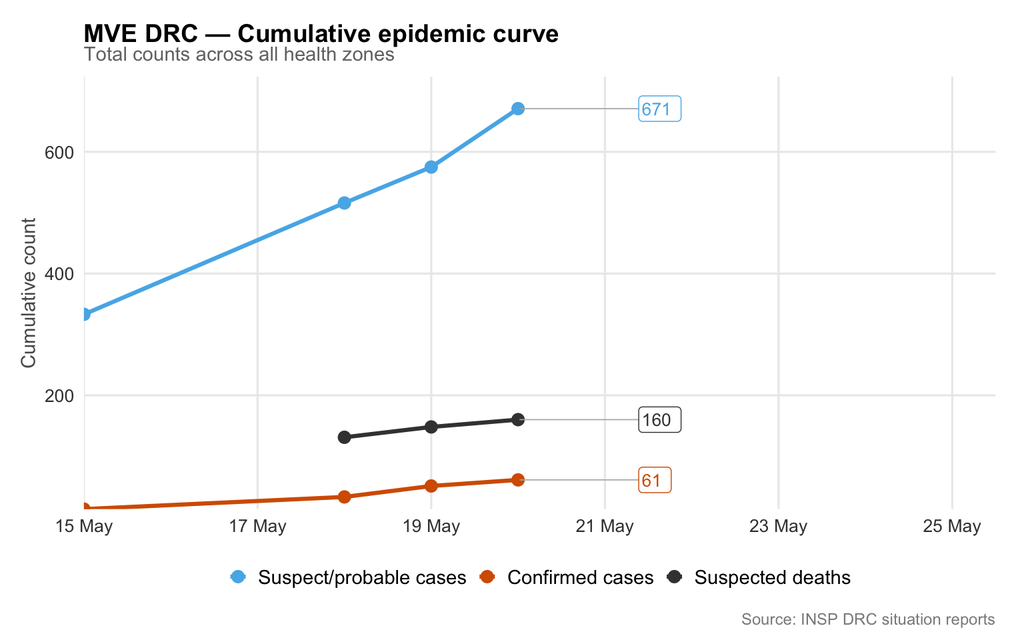

Figure 1: Cumulative MVE cases and deaths, DRC. Suspect and probable cases are combined. End-of-line labels show the latest recorded value. Source: INSP DRC.

### Daily new cases

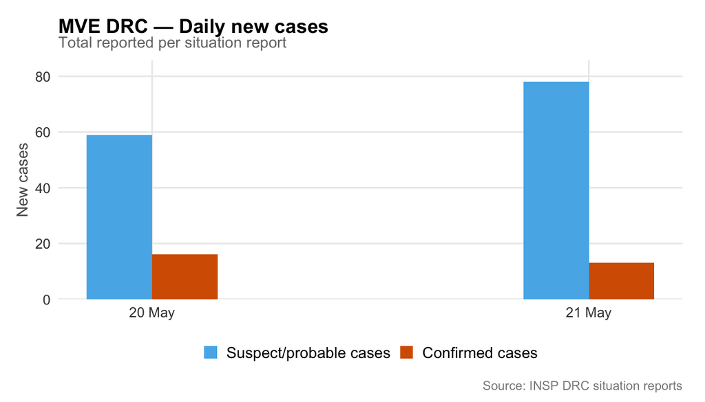

Figure 2: New cases reported per situation report across all health zones, DRC. Source: INSP DRC.

### Geographic distribution — cumulative counts

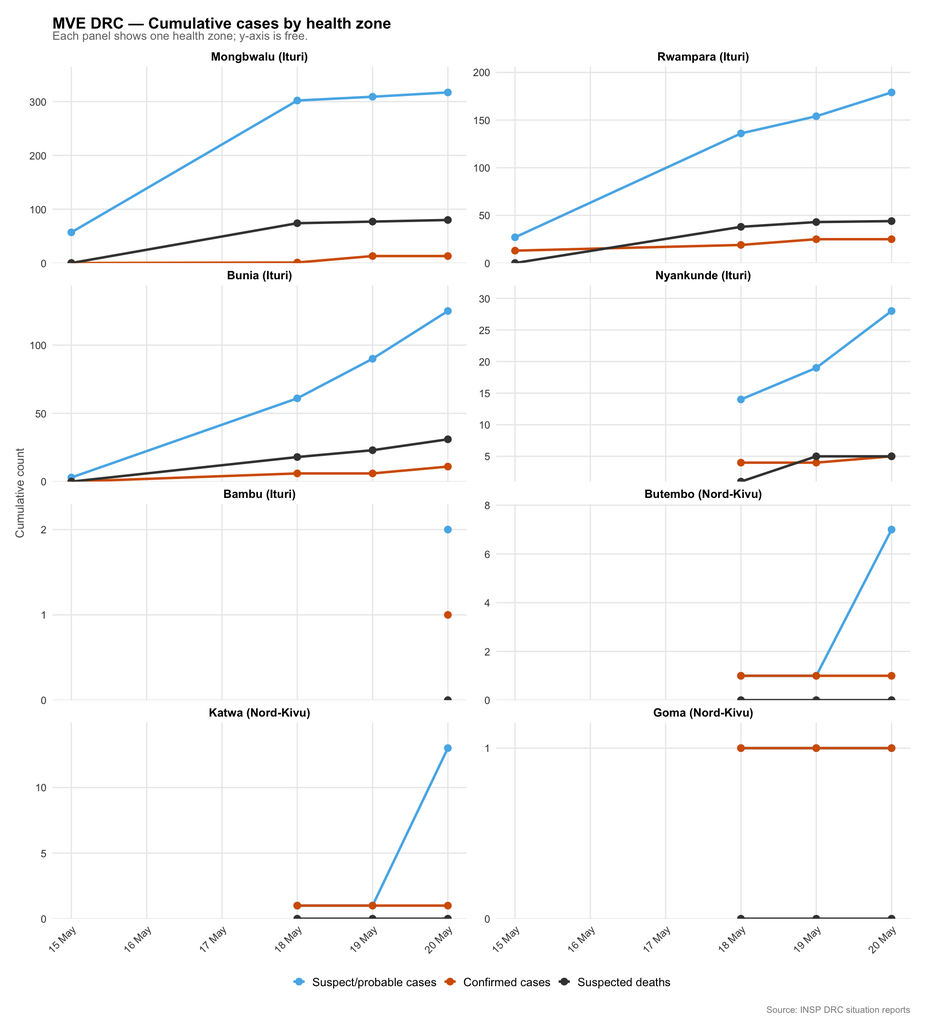

Figure 3: Cumulative cases by health zone. Y-axis is free across panels. Source: INSP DRC.

### Geographic distribution — new cases

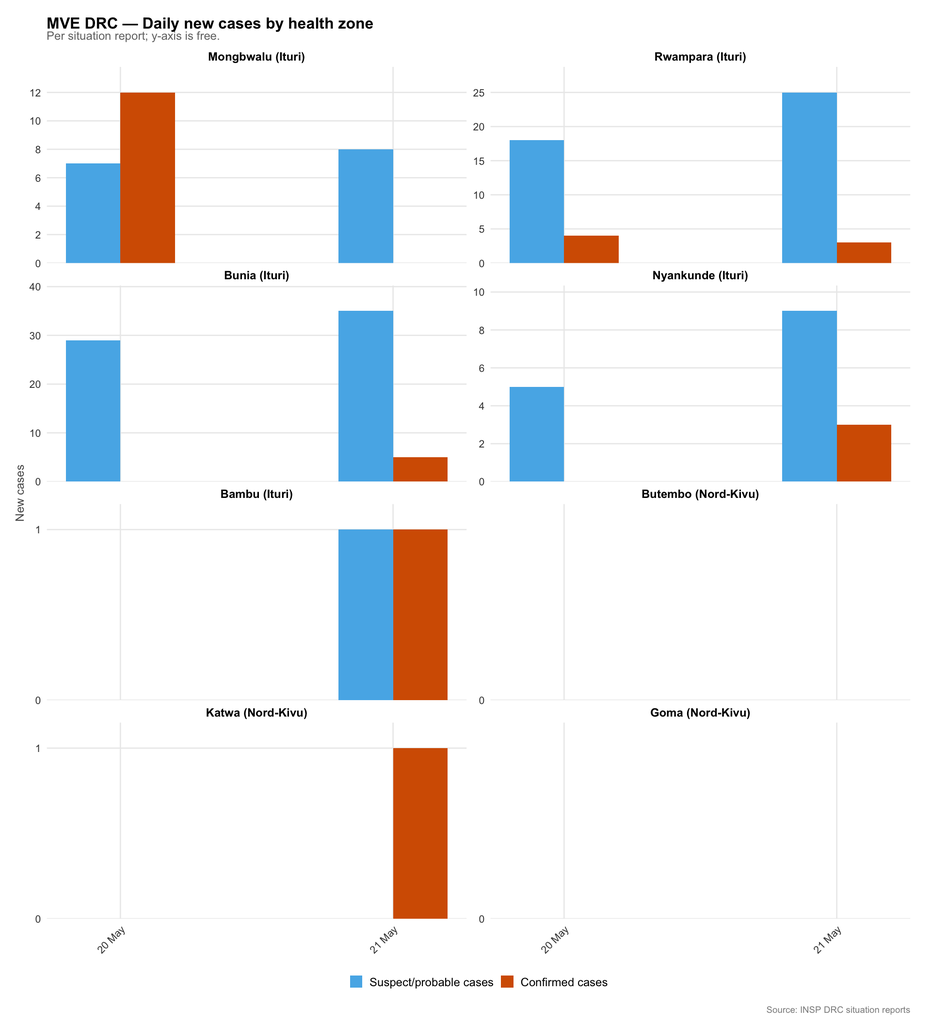

Figure 4: New cases per situation report by health zone. Y-axis is free across panels. Source: INSP DRC.

### Current counts by health zone

Table 1 presents the most recent cumulative case counts disaggregated by health zone, drawn from the latest available situation report for each zone.

Table 1: Table 1. Latest cumulative case counts by health zone.

[output not shown]

### Cross-source validation

Cumulative zone-level counts from this pipeline are compared against the [Kraemer lab Ebola DRC 2026](https://github.com/kraemer-lab/Ebola_DRC_2026) repository, which independently processes the same INSP SitRep PDFs into a standardised long-format. Zone names differ between sources at two sites (Mongbwalu/Mongbalu and Nyankunde/Nyakunde); counts are matched on the harmonised name. `ND` values in the Kraemer lab series (metric not reported on that date) are treated as missing.

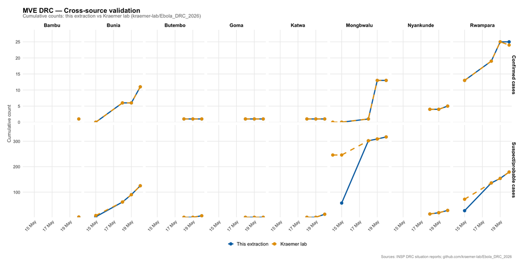

Figure 5: Cross-source comparison of cumulative confirmed and suspect/probable cases by health zone. Solid lines: this extraction; dashed lines: Kraemer lab. Sources: INSP DRC situation reports; github.com/kraemer-lab/Ebola_DRC_2026.

Table 2 presents numerical differences at the most recent date available in each source for each zone.

Table 2: Table 2. Cumulative case counts at the latest available date per zone: this extraction vs Kraemer lab. Delta = ours minus Kraemer. Dashes indicate no data in that source.

| Health zone | Confirmed (ours) | Confirmed (Kraemer) | Δ confirmed | Suspect/prob. (ours) | Suspect/prob. (Kraemer) | Δ suspect/prob. |
| --- | --- | --- | --- | --- | --- | --- |
| Bambu | 1 | 1 | 0 | 2 | 2 | 0 |
| Bunia | 11 | 11 | 0 | 125 | 125 | 0 |
| Butembo | 1 | 1 | 0 | 7 | 7 | 0 |
| Goma | 1 | 1 | 0 | 1 | 1 | 0 |
| Katwa | 1 | 1 | 0 | 13 | 13 | 0 |
| Mongbwalu | 13 | 13 | 0 | 317 | 317 | 0 |
| Nyankunde | 5 | 5 | 0 | 28 | 28 | 0 |
| Rwampara | 25 | 24 | 1 | 179 | 179 | 0 |

## Discussion

The outbreak trajectory shows a consistent increase in suspect and probable case counts across the reporting period. Confirmed cases remain a minority of the total, reflecting the challenges of laboratory confirmation in the field setting. The geographic spread across both Ituri and Nord-Kivu provinces underscores the need for multi-province coordination of the response.